# OPLA POLA RNAseq analysis

Felix Westcott

2022-01-19

# 1 Analysis methods

All analysis was conducted using [R](https://www.r-project.org/) and [RStudio](https://www.rstudio.com/). A variety of R packages were used for this analysis that are available from the Comprehensive R Archive Network (CRAN), Bioconductor.org, or Github. Differential gene expression analysis was carried our using the [EdgeR](https://www.ncbi.nlm.nih.gov/pmc/articles/PMC2796818/) package and functional enrichment analysis was carried out using clusterProfiler package. A full list of all packages used can be found at the bottom.

# 2 Preprocessing

## 2.1 Impact of filtering and normalization

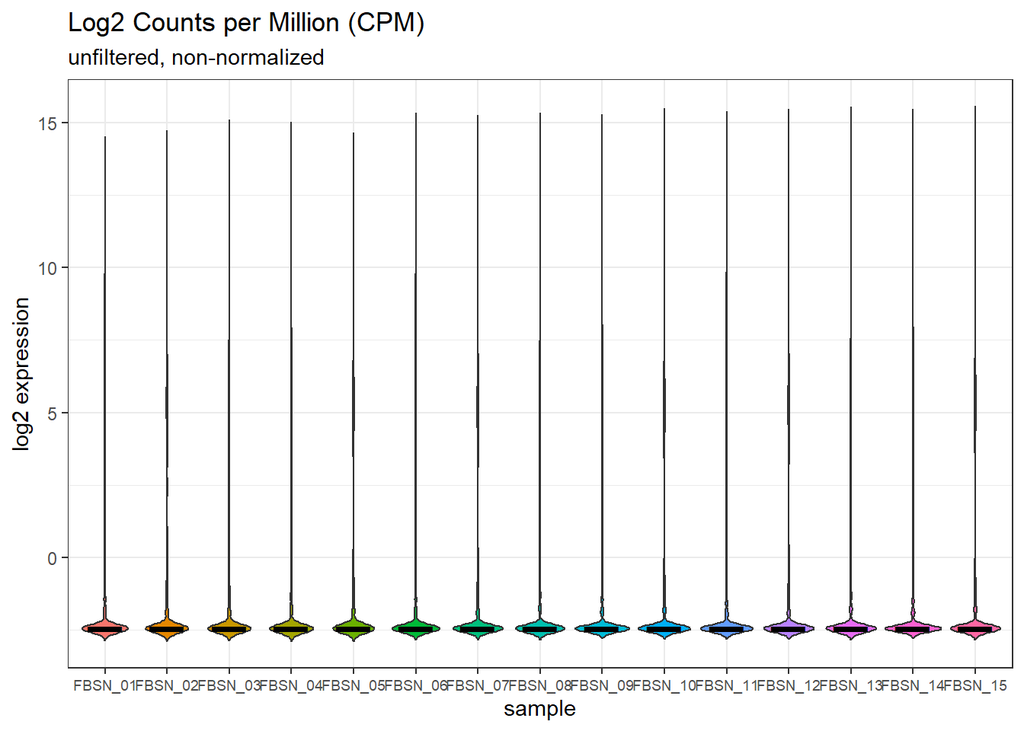

```r
# Load data
Raw_counts <- read.delim ('Counts.txt')
samplemetadata <-read.delim ('Sample_info.txt')
group <- factor(samplemetadata$fat_type)

# Turn raw count data into matrix with only relevant parts
geneID <- Raw_counts$gene_name
Raw_counts <- as.matrix(Raw_counts[,2:16])
rownames(Raw_counts) <- geneID

# Create a DGEList from raw count matrix
myDGEList <- DGEList(Raw_counts, group = group)

log2.cpm <- cpm(myDGEList, log=TRUE)


log2.cpm.df <- as_tibble(log2.cpm, rownames = "geneID")
log2.cpm.df.pivot <- pivot_longer(log2.cpm.df,
                                  cols = FBSN_01:FBSN_15,
                                  names_to = "samples",
                                  values_to = "expression")

ggplot(log2.cpm.df.pivot) +
  aes(x=samples, y=expression, fill=samples) +
  geom_violin(trim = FALSE, show.legend = FALSE) +
  stat_summary(fun = "median",
               geom = "point",
               shape = 95,
               size = 10,
               color = "black",
               show.legend = FALSE) +
  labs(y="log2 expression", x = "sample",
       title="Log2 Counts per Million (CPM)",
       subtitle="unfiltered, non-normalized") +
  theme_bw() +
   theme(axis.text.x = element_text(size = 7))
```

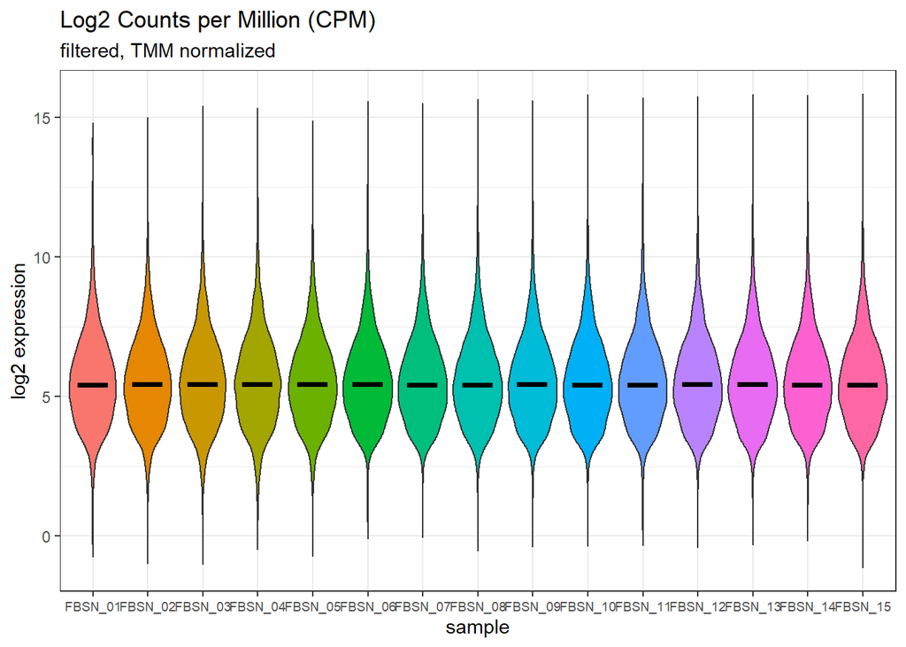

```r
# Filter data. NB this uses cpm but this will get calculated properly again later
cpm <- cpm(myDGEList, log=FALSE)
keep <- filterByExpr(cpm, group = group)
myDGEList.filtered <- myDGEList[keep,,keep.lib.sizes=FALSE]

# Normalize filtered data using TMM method
myDGEList.filtered.norm <- calcNormFactors(myDGEList.filtered, method = "TMM")

# Express filtered and normalised data in log2(cpm)
log2.cpm.filtered.norm <- cpm(myDGEList.filtered.norm, log=TRUE)

# Also have it as a dataframe in case it comes in handy
log2.cpm.filtered.norm.df <- as_tibble(log2.cpm.filtered.norm, rownames = "geneID")

log2.cpm.filtered.norm.df.pivot <- pivot_longer(log2.cpm.filtered.norm.df,
                                                cols = FBSN_01:FBSN_15,
                                                names_to = "samples",
                                                values_to = "expression")

ggplot(log2.cpm.filtered.norm.df.pivot) +
  aes(x=samples, y=expression, fill=samples) +
  geom_violin(trim = FALSE, show.legend = FALSE) +
  stat_summary(fun = "median",
               geom = "point",
               shape = 95,
               size = 10,
               color = "black",
               show.legend = FALSE) +
  labs(y="log2 expression", x = "sample",
       title="Log2 Counts per Million (CPM)",
       subtitle="filtered, TMM normalized") +
  theme_bw() +
   theme(axis.text.x = element_text(size = 7))
```

Raw count data was first filtered to remove genes with low expression across the samples and then normalized using the [TMM method](https://genomebiology.biomedcentral.com/articles/10.1186/gb-2010-11-3-r25). Filtering reduced the number of genes from 58735 to 9572. The output was then expressed as log2 counts per million (log2(cpm)).

## 2.2 Table of filtered and normalized data

```r
# Creating a log2cpm gene expression df with averages for each condition
Avg.gene_expression <- log2.cpm.filtered.norm.df %>%
  mutate(Control = (FBSN_01 + FBSN_02 + FBSN_03 + FBSN_04 + FBSN_05)/5,
         OPLA = (FBSN_06 + FBSN_07 + FBSN_08 + FBSN_09 + FBSN_10)/5,
         POLA = (FBSN_11 + FBSN_12 + FBSN_13 + FBSN_14 + FBSN_15)/5) %>%
    mutate_if(is.numeric, round, 2) %>%
  dplyr::select(geneID, Control, OPLA, POLA)

datatable(Avg.gene_expression,
          extensions = c('KeyTable', "FixedHeader"),
          filter = 'top',
          caption = 'Table 1: log2 CPM of filtered and normalised genes in Control, OPLA and POLA',
          options = list(keys = TRUE,
                         searchHighlight = TRUE,
                         pageLength = 10,
                         lengthMenu = c("10", "25", "50", "100")))
```

|  | geneID | Control | OPLA | POLA |
| --- | --- | --- | --- | --- |
| 1 | AFP | 14.3 | 14.98 | 15.12 |
| 2 | EEF1A1 | 13.88 | 14.26 | 14.18 |
| 3 | ALB | 14.01 | 13.59 | 13.6 |
| 4 | FTL | 12.63 | 12.68 | 12.47 |
| 5 | EEF2 | 12.21 | 12.05 | 11.89 |
| 6 | RPL13A | 11.87 | 12.08 | 11.91 |
| 7 | RPSA | 11.52 | 12.15 | 12.1 |
| 8 | SCD | 12.43 | 11.61 | 11.61 |
| 9 | RPLP0 | 11.84 | 12.02 | 11.9 |
| 10 | TF | 11.71 | 11.98 | 11.66 |

[output cut: 9562 more lines]

# 3 Principle component ananlysis

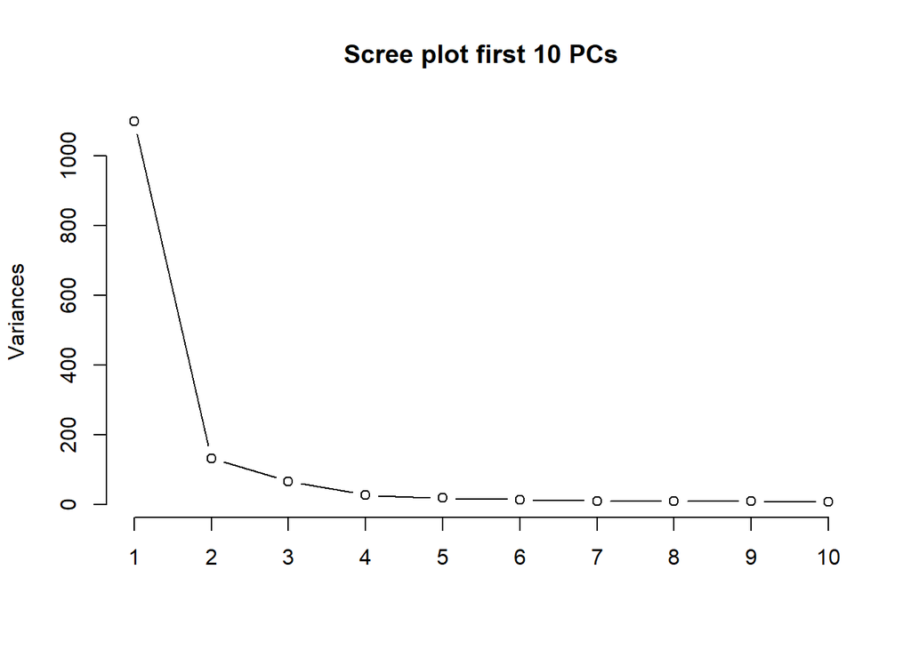

```r
#This is exactly the same as before, I just added the summary print out

pca.res <- prcomp(t(log2.cpm.filtered.norm), scale.=F, retx=T)
pc.var<-pca.res$sdev^2
pc.per<-round(pc.var/sum(pc.var)*100, 1)

screeplot(pca.res, type = "l", main = "Scree plot first 10 PCs")
```

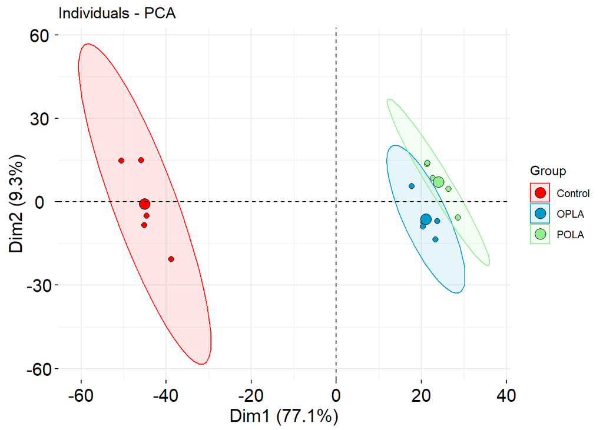

```r
#This is exactly the same as before I think

fviz_pca_ind(pca.res, geom.ind = "point", pointshape = 21,
             pointsize = 2,
             fill.ind = group,
             palette = c("red","deepskyblue3","lightgreen"),
             col.ind = "black",
             addEllipses = TRUE,
             label = "var",
             col.var = "black",
             repel = TRUE,
             legend.title = "Group") +
   theme(axis.text.x = element_text(color = "black", size = 15, angle = 0, hjust = .5, vjust = .5, face = "plain"),
      axis.text.y = element_text(color = "black", size = 15, angle = 0, hjust = .5, vjust = .5, face = "plain"),
      axis.title.x = element_text(color = "black", size = 15, angle = 0, hjust = .5, vjust = .5, face = "plain"),
      axis.title.y = element_text(color = "black", size = 15, angle = 90, hjust = .5, vjust = .5, face = "plain"))
```

Principle component analysis showed that the first two components accounted for 86.4% of the variation in the data. So these components were plotted.

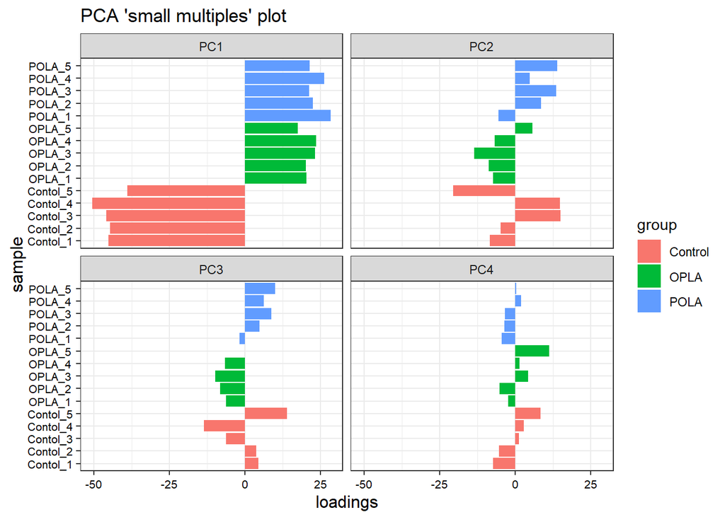

```r
# This is all new so I'll explain what I'm doing.

# Take results of first four PCAs and turn into tibble with sample names and fat types as added rows

pca.res.df <- pca.res$x[,1:4] %>%
  as_tibble() %>%
  add_column(sample = samplemetadata$sample_name,
             group = group)

#Pivot the table to make it tidy and easier to facet graph

pca.pivot <- pivot_longer(pca.res.df,
                          cols = PC1:PC4,
                          names_to = "PC",
                          values_to = "loadings")

#Graph - this graph illustrates if there are any obvious confounding variables among your samples (ie batch effects etc.)

ggplot(pca.pivot) +
  aes(x=sample, y=loadings, fill=group) +
  geom_bar(stat="identity") +
  facet_wrap(~PC) +
  labs(title="PCA 'small multiples' plot") +
  theme_bw() +
  coord_flip() +
theme(axis.text.x = element_text(color = "black", size = 8, angle = 0, hjust = .5, vjust = .5, face = "plain"),
      axis.text.y = element_text(color = "black", size = 8, angle = 0, hjust = .5, vjust = .5, face = "plain"),
      axis.title.x = element_text(color = "black", size = 12, angle = 0, hjust = .5, vjust = .5, face = "plain"),
      axis.title.y = element_text(color = "black", size = 12, angle = 90, hjust = .5, vjust = .5, face = "plain"))
```

The other four components were also plotted. PC1 clearly shows the variation between OPLA/POLA and Controls whereas PC2 and PC3 show the variation between OPLA and POLA. PC4 could be a possible batch effect showing the variation in early vs late rounds.

# 4 Differential gene expression

## 4.1 Volcano Plots

Differential gene expression analysis was carried out using the using [EdgeR](https://www.ncbi.nlm.nih.gov/pmc/articles/PMC2796818/) and volcano plots were generated with an adjusted p-value (/false discovery rate) cutoff of <0.01 and lof fold-change cutoff of 0.2.

```r
# Pretty much all the same as before I just tidied this up quite a bit and put it all in one place for you

# Design matrix - exactly the same as before
design <- model.matrix(~0 + group)
colnames(design) <- levels(group)

# Contrast matrix - slight changes to before just to tidy up
contrast.matrix1 <- makeContrasts(OPLAvsControl = OPLA-Control, levels=design)
contrast.matrix2 <- makeContrasts(POLAvsControl = POLA-Control, levels=design)
contrast.matrix3 <- makeContrasts(POLAvsOPLA = POLA-OPLA, levels=design)

# Estimate common dispersion, trended dispersions and tagwise dispersions from filtered and normalized raw data (ie not cpm or log)
y <- estimateDisp(myDGEList.filtered.norm, design, robust = TRUE)
fit <- glmFit(y, design)

# Likelihood ratio test OPLA vs Control.
res1 <- glmLRT(fit, contrast = contrast.matrix1)
results1 <- topTags (res1, sort.by = NULL, n=Inf, adjust.method = "BH")
toptable1 <- results1$table %>%
  as_tibble(rownames = "geneID")

# Likelihood ratio test POLA vs Control.
res2 <- glmLRT(fit, contrast = contrast.matrix2)
results2 <- topTags (res2, sort.by = NULL, n=Inf, adjust.method = "BH")
toptable2 <- results2$table %>%
  as_tibble(rownames = "geneID")

# Likelihood ratio test POLA vs OPLA.
res3 <- glmLRT(fit, contrast = contrast.matrix3)
results3 <- topTags (res3, sort.by = NULL, n=Inf, adjust.method = "BH")
toptable3 <- results3$table %>%
  as_tibble(rownames = "geneID")

# NB: FDR column is adjusted p-value using BH correction for multiple comparisons

DGEResults <- cbind(toptable1$geneID, toptable1$logFC, toptable2$logFC, toptable3$logFC, toptable1$FDR, toptable2$FDR, toptable3$FDR) %>%
  as.data.frame() %>%
  rename(geneID = V1, "OPLA vs Control LogFC" = V2, "POLA vs Control logFC" = V3, "POLA vs OPLA logFC" = V4, "OPLA vs Control p.adj" = V5, "POLA vs Control p.adj" = V6, "POLA vs OPLA p.adj" = V7)
```

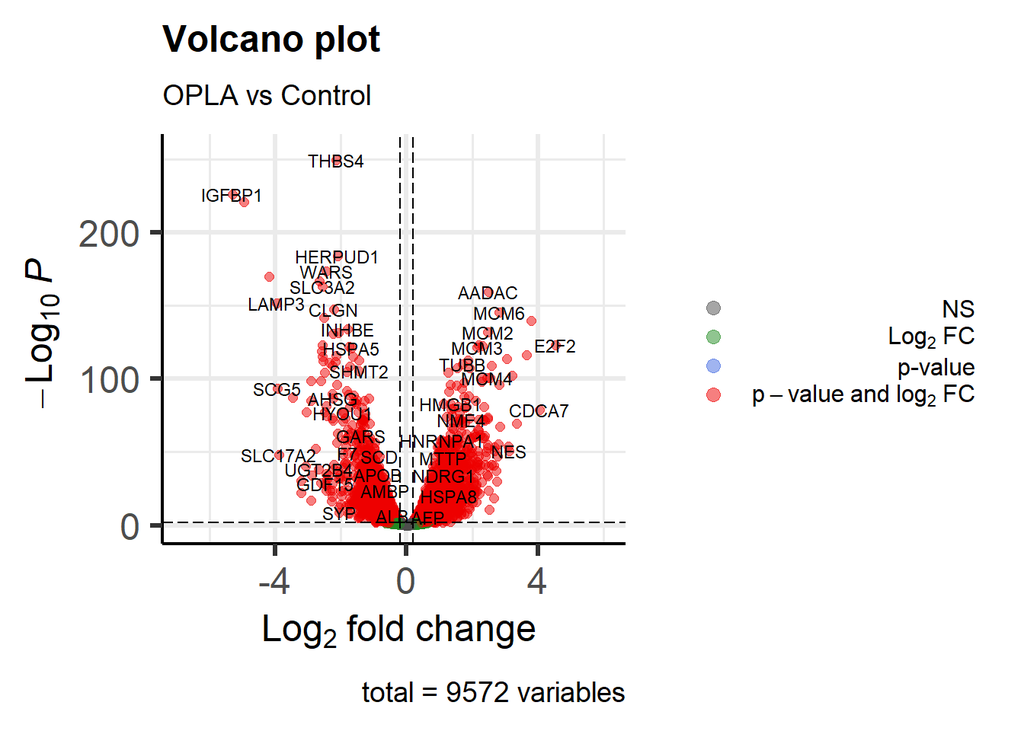

```r
# Almost exactly the same just all in one place and made to look better

EnhancedVolcano(toptable1,
    lab = toptable1$geneID,
    x = 'logFC',
    y = 'FDR',
    legendPosition = "right",
    legendLabSize = 12,
    legendIconSize = 3,
    labSize = 3,
    subtitle = "OPLA vs Control",
    pCutoff = 0.01,
    FCcutoff = 0.2)
```

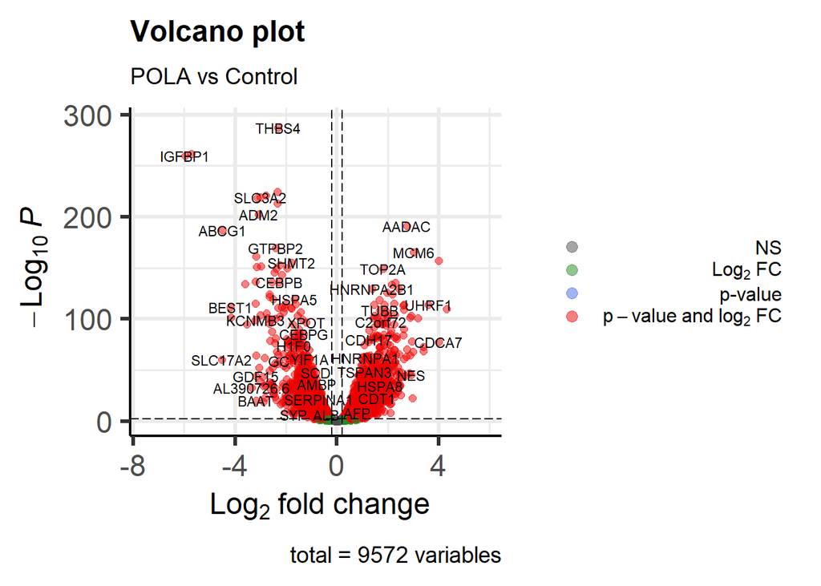

```r
EnhancedVolcano(toptable2,
    lab = toptable2$geneID,
    x = 'logFC',
    y = 'FDR',
    legendPosition = "right",
    legendLabSize = 12,
    legendIconSize = 3,
    labSize = 3,
    subtitle = "POLA vs Control",
    pCutoff = 0.01,
    FCcutoff = 0.2)
```

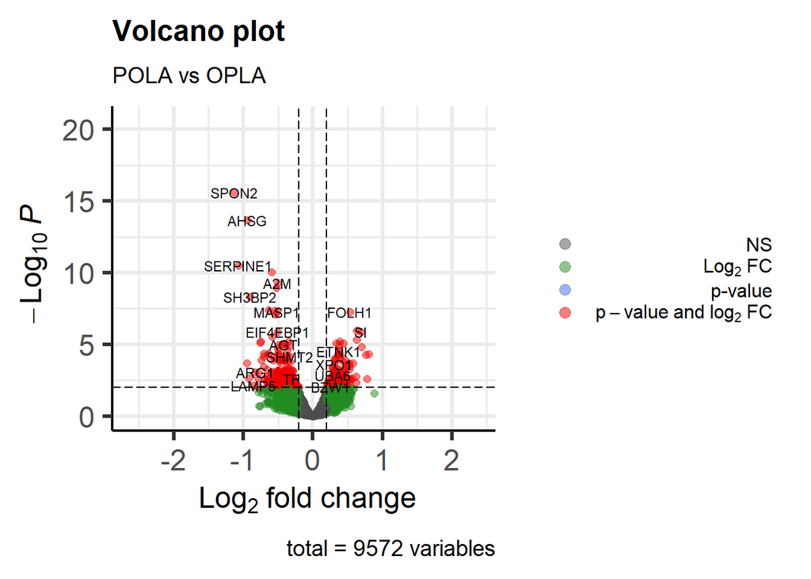

```r
EnhancedVolcano(toptable3,
    lab = toptable3$geneID,
    x = 'logFC',
    y = 'FDR',
    legendPosition = "right",
    legendLabSize = 12,
    legendIconSize = 3,
    labSize = 3,
    subtitle = "POLA vs OPLA",
    pCutoff = 0.01,
    FCcutoff = 0.2)
```

## 4.2 Table of differentially expressed genes

```r
# Decide tests go through the results of the differential gene expression analysis and catagorizes each gene into either significant up, down-regulation or no significnat change (1,-1 and 0 respectively). IMPORTANT - p.value and lfc are obviously the p-value and lfc cutoff for if genes are classed as differentially expressed. These can and probably should be changed and will have an impact on the results from here on. Currently set to same parameters as the volcano plots are.

Decision_results1 <- decideTests(res1, method="global", adjust.method="BH", p.value=0.01, lfc = 0.2)
Decision_results2 <- decideTests(res2, method="global", adjust.method="BH", p.value=0.01, lfc = 0.2)
Decision_results3 <- decideTests(res3, method="global", adjust.method="BH", p.value=0.01, lfc = 0.2)

# I've combined the results of these three combine tests to have a column for each comparison
Decision_results <- as_tibble(cbind(Decision_results1, Decision_results2, Decision_results3), rownames = "geneID")

# Here I've taken our average gene expression df we made and ask it to keep all the genes with a significant lfc as decided by the results of our decision tests
diffGenes.avg <- Avg.gene_expression[Decision_results[,2] !=0 | Decision_results[,3] !=0 | Decision_results[,4] !=0,]
diffGenes.avg.df <- as_tibble(diffGenes.avg)

# Created interactive and searchable table of all the significantly differentially expressed genes
datatable(diffGenes.avg.df,
          extensions = c('KeyTable', "FixedHeader"),
          caption = 'Table 2: log2 CPM of DEGs in Control, OPLA and POLA',
          options = list(keys = TRUE, searchHighlight = TRUE, pageLength = 10, lengthMenu = c("10", "25", "50", "100"))) %>%
  formatRound(columns=c(2:4), digits=2)
```

|  | geneID | Control | OPLA | POLA |
| --- | --- | --- | --- | --- |
| 1 | AFP | 14.3 | 14.98 | 15.12 |
| 2 | EEF1A1 | 13.88 | 14.26 | 14.18 |
| 3 | ALB | 14.01 | 13.59 | 13.6 |
| 4 | EEF2 | 12.21 | 12.05 | 11.89 |
| 5 | RPL13A | 11.87 | 12.08 | 11.91 |
| 6 | RPSA | 11.52 | 12.15 | 12.1 |
| 7 | SCD | 12.43 | 11.61 | 11.61 |
| 8 | TF | 11.71 | 11.98 | 11.66 |
| 9 | SERPINA1 | 12.07 | 11.52 | 11.37 |
| 10 | AMBP | 12.1 | 11.45 | 11.29 |

[output cut: 6667 more lines]

In total 6677 were significantly differentially expressed between at least two of the conditions and these are displayed in the table above.

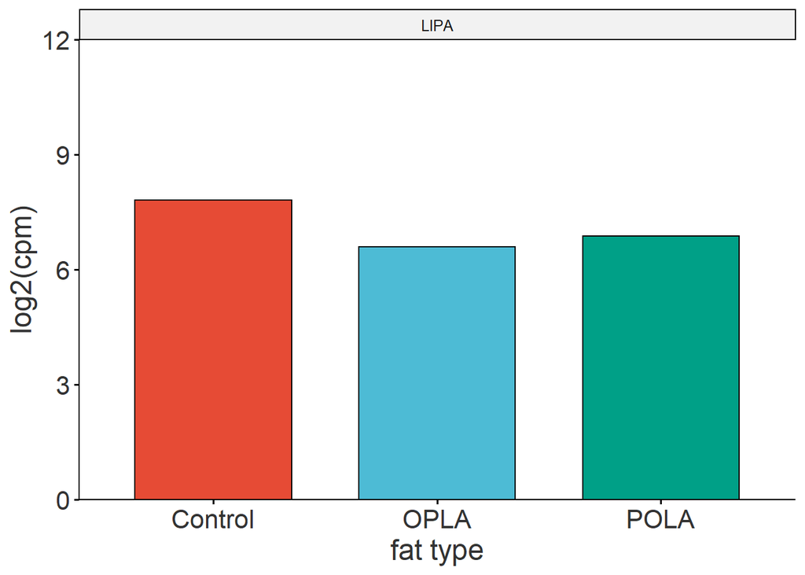

```r
# Pivot to tidy up data
diffGenes.avg.df.pivot <- pivot_longer(diffGenes.avg.df,
                          cols = Control : POLA,
                          names_to = "fat type",
                          values_to = "log2(cpm)")

#  Filter for genes you want. grepl will pick out any with that phrase in it. Use " x | y | z | etc." notation to search for multiple genes.
graph <- diffGenes.avg.df.pivot %>%
  dplyr::filter(grepl('LIPA', geneID))

# Graph error bars were a set too far for me as they got messed up with the facet wrap
ggbarplot(graph, "fat type", "log2(cpm)", palette = "npg", legend = "none", fill = "fat type") +
  facet_wrap(~geneID) +
  scale_y_continuous(expand = c(0,0), limits = c(0, 12)) +
theme(axis.text.x = element_text(color = "grey20", size = 16),
axis.text.y = element_text(color = "grey20", size = 16),
axis.title.x = element_text(color = "grey20", size = 18),
axis.title.y = element_text(color = "grey20", size = 18))
```

Individual genes can be searched and graphed as shown above with LIPA gene as an example.

## 4.3 Venn Diagrams

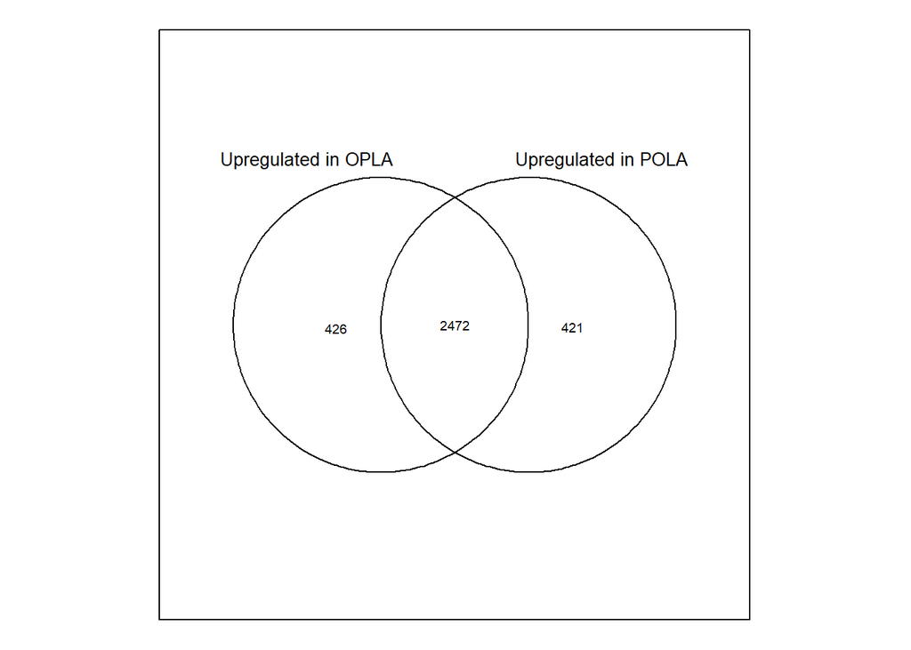

```r
#This is exactly the same as before I have just used the decision results from earlier to filter for up and down regulated genes instead of doing it manually

venn_opla_up <- toptable1[Decision_results[,2] >0,]
venn_opla_down <- toptable1[Decision_results[,2] <0,]
venn_pola_up <- toptable2[Decision_results[,3] >0,]
venn_pola_down <- toptable2[Decision_results[,3] <0,]

venn_up <-merge(venn_opla_up,venn_pola_up, by= "geneID", all.x=TRUE, all.y=TRUE)

OPLA_up <- venn_up[!is.na(venn_up$logFC.x), "geneID"]
POLA_up <- venn_up[!is.na(venn_up$logFC.y), "geneID"]
input_up <-list("Upregulated in OPLA"=OPLA_up, "Upregulated in POLA"=POLA_up)
venn(input_up)
```

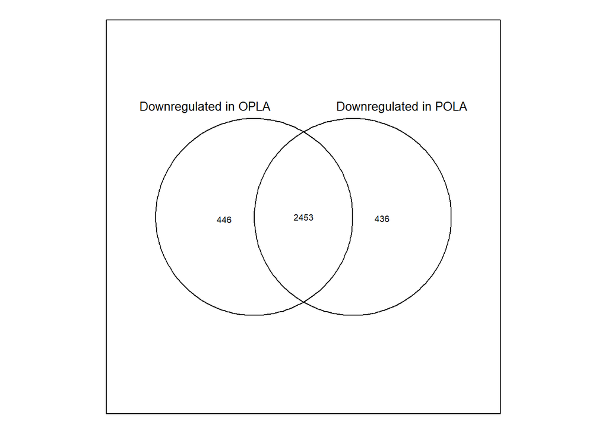

```r
venn_down <-merge(venn_opla_down,venn_pola_down, by= "geneID", all.x=TRUE, all.y=TRUE)

OPLA_down <- venn_down[!is.na(venn_down$logFC.x), "geneID"]
POLA_down <- venn_down[!is.na(venn_down$logFC.y), "geneID"]
input_down <-list("Downregulated in OPLA"=OPLA_down, "Downregulated in POLA"=POLA_down)
venn(input_down)
```

Venn Diagrams were plotted with the overlap showing the number of genes up- or downregulated in both conditions compared to controls.

## 4.4 Heatmaps and modules

Identified differentially expressed genes were clustered using pearson correlation and a heatmap was generated with data scaled by z-score for each row. Spearman correlation was used to cluster the samples.

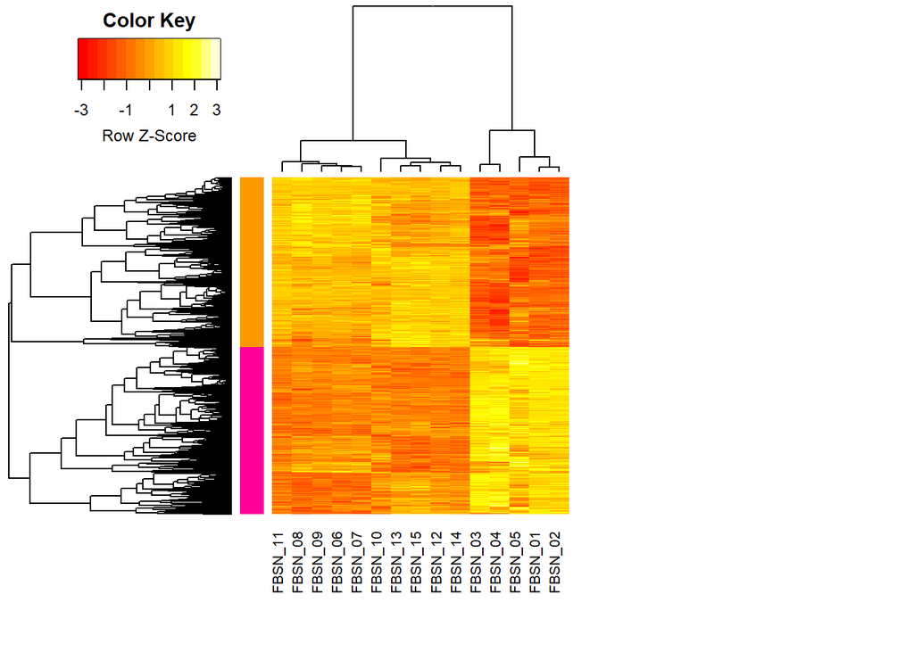

```r
# I'm again using that big Decision results table to filter out all non-significant differential expressed genes from our log2cpm data
diffGenes <- log2.cpm.filtered.norm.df[Decision_results[,2] !=0 | Decision_results[,3] !=0 | Decision_results[,4] !=0,] %>%
  column_to_rownames(var="geneID") %>%
  as.matrix

# This is just stuff for the dendrogram to do clustering. Trust me, I copied it off the internet.
clustRows <- hclust(as.dist(1-cor(t(diffGenes), method="pearson")), method="complete")
clustColumns <- hclust(as.dist(1-cor(diffGenes, method="spearman")), method="complete")

# Change K = it you want to cluster you genes into more than two (change it and you'll see what I mean)
module.assign <- cutree(clustRows, k=2)

# Boring code just to get the little colour bar by the side of the genes
module.color <- rainbow(length(unique(module.assign)), start=0.1, end=0.9)
module.color <- module.color[as.vector(module.assign)]

# Actual heatmap
heatmap.2(diffGenes,
          Rowv=as.dendrogram(clustRows),
          Colv=as.dendrogram(clustColumns),
          RowSideColors=module.color,
          scale='row', labRow=NA,
          density.info="none", trace="none",
          cexRow=1, cexCol=1, margins=c(8,20))
```

Groups of genes can be selected from the same heatmap such as the ATG genes as shown below.

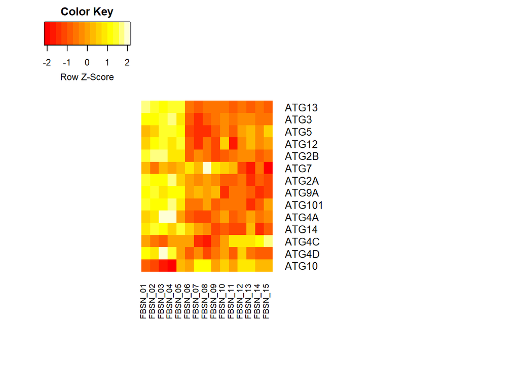

```r
# Change whatever is in the filter function to change which genes are plotted
selected_genes <- diffGenes %>%
  as_tibble(rownames = "geneID") %>%
  dplyr::filter(grepl('ATG', geneID)) %>%
 column_to_rownames(var="geneID") %>%
  as.matrix

# I stripped this one down a lot because otherwise was a bit OTT
heatmap.2(selected_genes,
          Rowv= NULL,
          Colv=NULL,
          dendrogram = 'none',
          scale='row',
          density.info="none", trace="none",
          cexRow= 1, cexCol=0.8, margins=c(8,20))
```

# 5 Functional enrichment analysis

Functional enrichment analysis was carried out using [clusterProfiler](https://www.ncbi.nlm.nih.gov/pmc/articles/PMC3339379/) which mapped differentially expressed genes onto themes and compared to those that in an entire human genome.

## 5.1 OPLA versus control

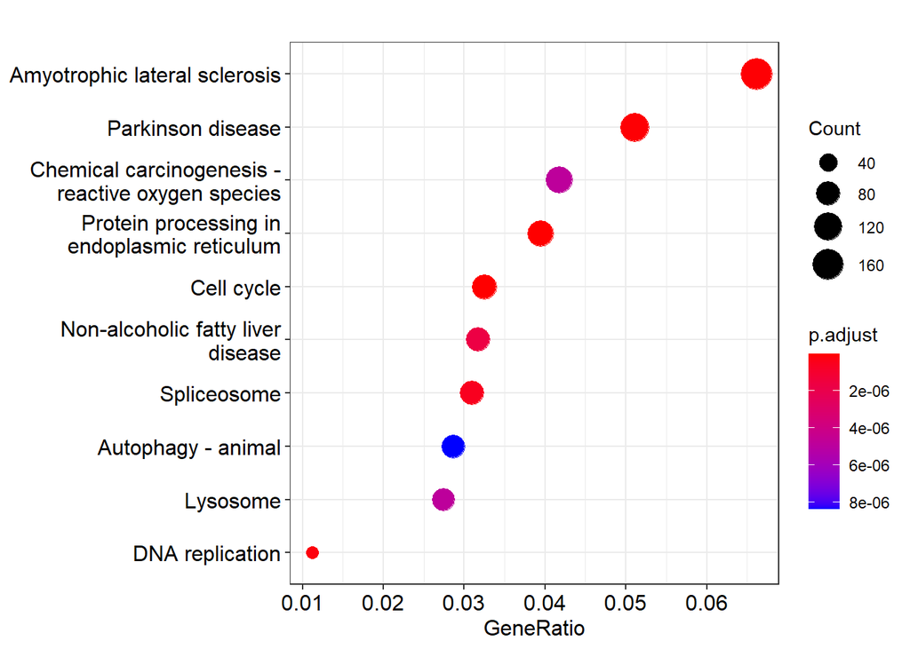

```r
#This is actually almost all the same as before just slightly modified first step

diffGenes.OPLA <- toptable1[Decision_results[,2] !=0,] %>%
rename("SYMBOL" = geneID)

entrez <- bitr(diffGenes.OPLA$SYMBOL, fromType = "SYMBOL",
                 toType = "ENTREZID",
                 OrgDb="org.Hs.eg.db")

deg_opla_enrich <- diffGenes.OPLA %>% left_join(entrez,.,by="SYMBOL")

ekegg_deg_OPLA_list <- enrichKEGG(gene = deg_opla_enrich$ENTREZID,
                    organism = 'hsa')

edox_deg_opla_list <- setReadable(ekegg_deg_OPLA_list, 'org.Hs.eg.db', 'ENTREZID')

dotplot(edox_deg_opla_list, showCategory=10)
```

## 5.2 POLA versus control

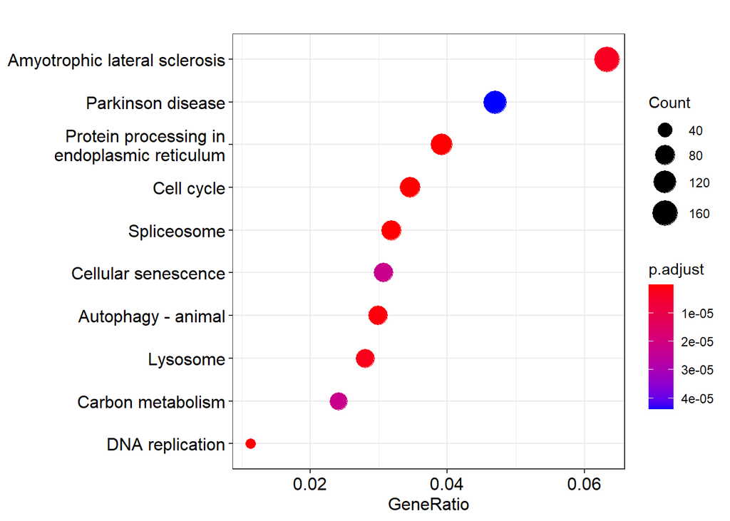

```r
# same as before
diffGenes.POLA <- toptable2[Decision_results[,3] !=0,] %>%
  rename("SYMBOL" = geneID)

entrez <- bitr(diffGenes.POLA$SYMBOL, fromType = "SYMBOL",
                 toType = "ENTREZID",
                 OrgDb="org.Hs.eg.db")

deg_pola_enrich <- diffGenes.POLA %>% left_join(entrez,.,by="SYMBOL")

ekegg_deg_POLA_list <- enrichKEGG(gene = deg_pola_enrich$ENTREZID,
                    organism = 'hsa')

edox_deg_pola_list <- setReadable(ekegg_deg_POLA_list, 'org.Hs.eg.db', 'ENTREZID')

dotplot(edox_deg_pola_list, showCategory=10)
```

# 6 Pathway enrichment anaysis

The package [pathview](https://pathview.uncc.edu/) uses [KEGG pathways](https://www.genome.jp/kegg/pathway.html) to map significantly differentially expressed genes onto biological pathways showing their up or down regulation. Shown here is the pathway for autophagy.

## 6.1 OPLA versus control

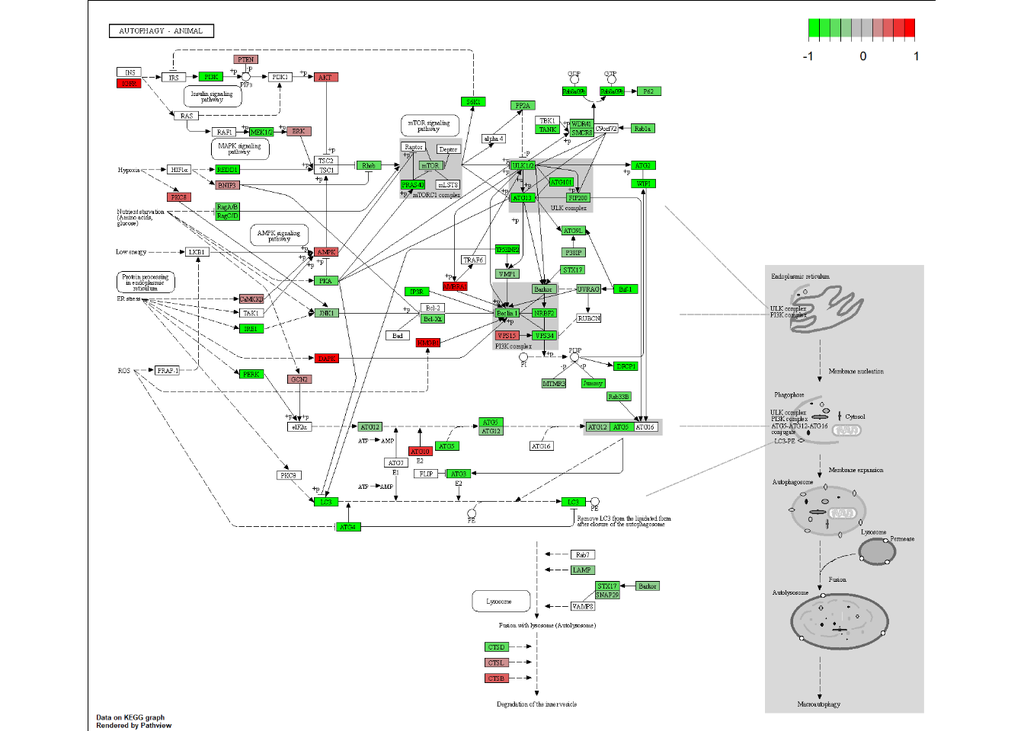

```r
setwd("C:/Users/fwestcott/OneDrive - Nexus365/Desktop/Results/OPLA-POLA-huh7-RNAseq/Pathview")

#This is the same as before
fc.vector <- as.numeric(deg_opla_enrich[, 3])
names(fc.vector) <- (deg_opla_enrich[, 2])
de.names <- names(fc.vector)

pathview(gene.data  = fc.vector, pathway.id = "hsa04140",species  = "hsa")

img <- readPNG('hsa04140.pathview.png')
grid.raster(img)
```

## 6.2 POLA versus control

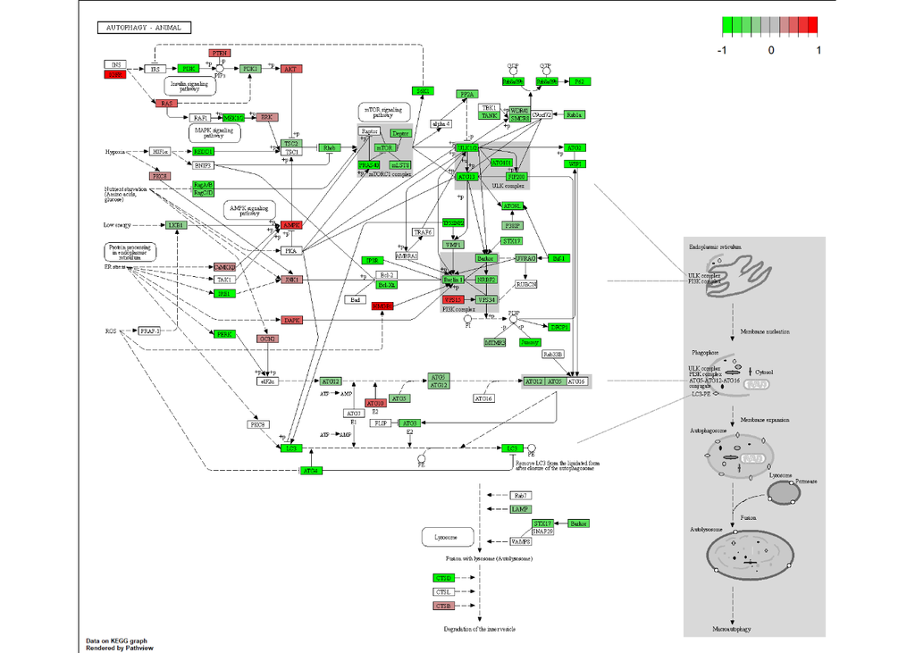

```r
setwd("C:/Users/fwestcott/OneDrive - Nexus365/Desktop/Results/OPLA-POLA-huh7-RNAseq/Pathview")

#This is the same as before
fc.vector <- as.numeric(deg_pola_enrich[, 3])
names(fc.vector) <- (deg_pola_enrich[, 2])
de.names <- names(fc.vector)

pathview(gene.data  = fc.vector, pathway.id = "hsa04140",species  = "hsa")

img <- readPNG('hsa04140.pathview.png')
grid.raster(img)
```

## 6.3 POLA versus OPLA

[figure not shown]

```r
setwd("C:/Users/fwestcott/OneDrive - Nexus365/Desktop/Results/OPLA-POLA-huh7-RNAseq/Pathview")

diffGenes.POLA.OPLA <- toptable3[Decision_results[,4] !=0,] %>%
  rename("SYMBOL" = geneID)

entrez <- bitr(diffGenes.POLA.OPLA$SYMBOL, fromType = "SYMBOL",
                 toType = "ENTREZID",
                 OrgDb="org.Hs.eg.db")

deg_pola_opla_enrich <- diffGenes.POLA.OPLA %>% left_join(entrez,.,by="SYMBOL")

fc.vector <- as.numeric(deg_pola_opla_enrich[, 3])
names(fc.vector) <- (deg_pola_opla_enrich[, 2])
de.names <- names(fc.vector)

pathview(gene.data  = fc.vector, pathway.id = "hsa04110",species  = "hsa")

img <- readPNG('hsa04140.pathview.png')
grid.raster(img)
```

# 7 Conclusions

Autophagy generally appears to decrease in OPLA and POLA compared to controls.

# 8 Session info

The output from running ‘sessionInfo’ is shown below and details all packages and version necessary to reproduce the results in this report.

[session information not shown]